# UNICEF_Report_on_C-Section_Births

# Global Trends in Cesarean Section Births

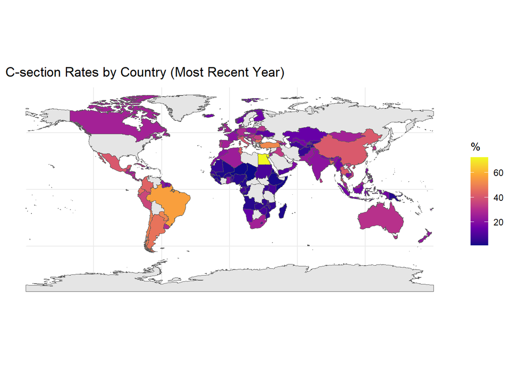

This is a world map showing how often babies are born by C-section (Cesarean section) in different countries, based on the most recent data available. Each country is colored depending on how high or low their C-section rate is.

Countries in pink and purple shades have lower rates, around 20% to 40%.

Places that are dark purple or almost blue have very low rates, under 20%.

On the right side, there’s a color bar that acts like a key, showing you how the colors match to percentages.

If you look closely:

South America, especially countries like Brazil, stands out in bright colors — meaning lots of babies are born by C-section there.

Africa mostly shows darker colors — meaning fewer C-sections.

Europe and parts of Asia are a mix, with some countries having moderate to high rates.

Some countries are gray, meaning there’s no available data for them.

In short, this map is like a colorful snapshot showing that C-section births are very common in some places but much rarer in others.

[figure not shown]

This is a bar chart that shows how often babies are delivered by C-section (Cesarean section) in three countries: **Yemen**, **Afghanistan**, and **Mozambique**.

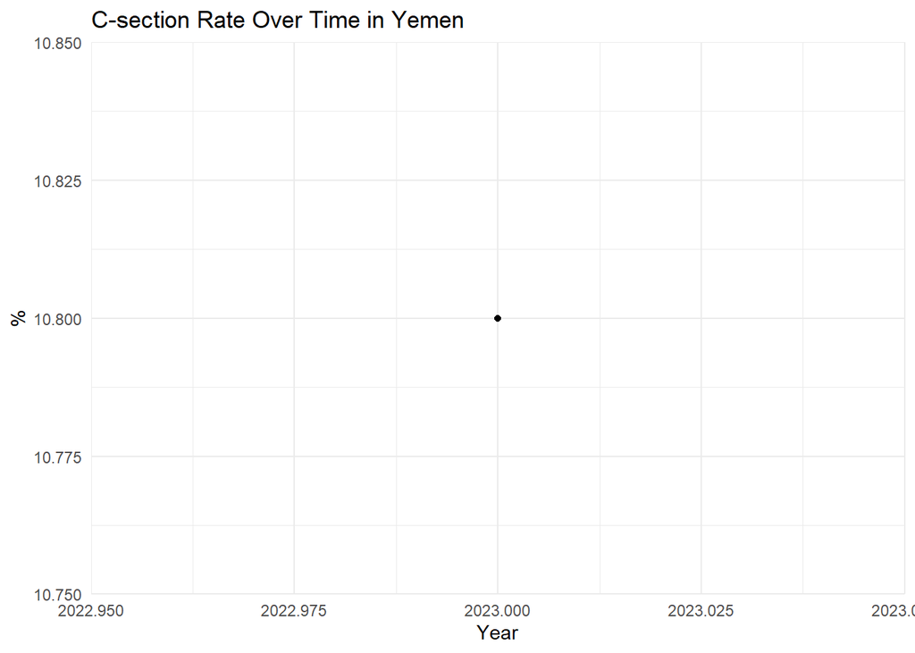

This chart is about **C-section rates in Yemen** over time.

- The X-axis (bottom) shows the **year** — here it’s only **2023**.
- The Y-axis (side) shows the **C-section rate in percentage**.
- There’s just **one small black dot** on the chart, sitting at around **10.8%**.

What this means:

We only have **one data point** for Yemen — from the year 2023.

It tells us that in 2023, **about 10.8% of babies** in Yemen were delivered by C-section.

There’s no line or trend because there’s no data for earlier years to connect.

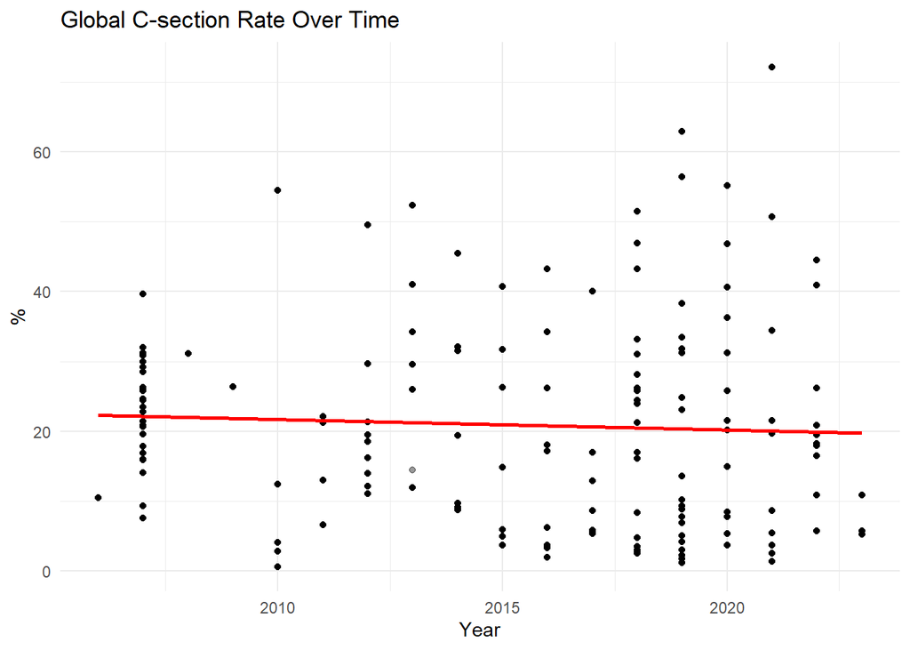

Every **small black dot** represents the C-section rate for one country in a particular year.

The **red line** shows the overall trend — kind of like the “big picture” of what’s happening.

When we look at it:

The black dots are spread out — some countries have low C-section rates, some have really high ones.

The red line is **slightly going down over time**, meaning that **overall**, the average C-section rate across the world might be decreasing a little bit.

However, there are still a lot of countries with high C-section rates scattered through the years.

**Conclusion:**  
C-section rates are different all over the world. Some countries have very high rates, while others have very low rates. Overall, around the world, the average C-section rate has stayed mostly the same over the past few years. Good, accurate data is important because sometimes mistakes can happen and make the results look wrong.

In short, C-sections are common in some places, rare in others, and we need good information to really understand the situation.